# 190918(6주차)_복습

BITAmin 3조

### 6주차 *[데이터 시각화]* 복습문제

#### **p1**

#### geom_bar를 이용해 diamonds 데이터에서 clarity 별로 count 그래프를 그리시오.

#### (diamonds 데이터는 ggplot2 패키지 안에 있음)

1. 이때, 각 clarity마다 cut 별로 색이 구분되도록 해야 하며, 누적되지 않고 막대는 분리되어 있어야 함
2. 타이틀은 “Diamonds”이며, 굵은 이탤릭체, 크기는 30, 가운데 정렬을 맞춰야 함
3. 테마는 dark로 지정

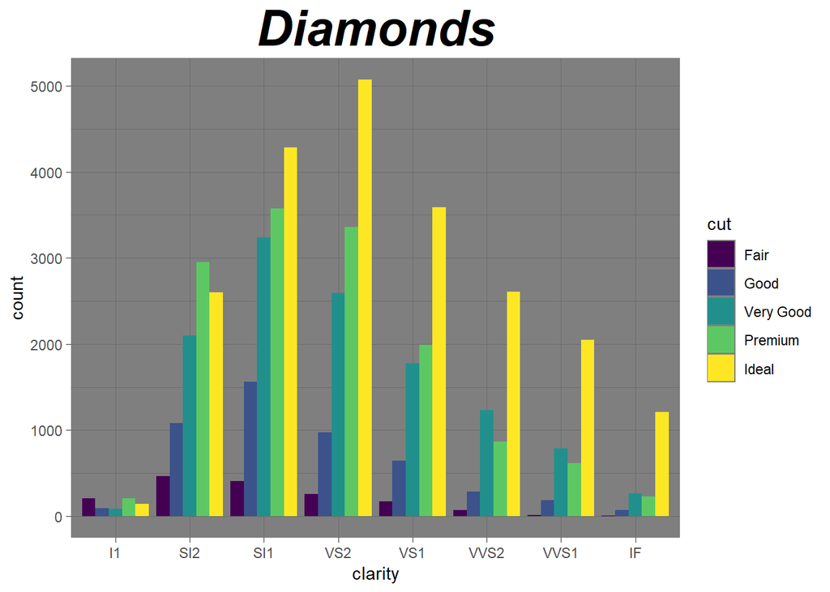

#### **p2**

#### geom_boxplot을 이용해 mpg 데이터에서 class 별로 cty(도시 연비) 상자 수염 그림을 그리시오. (mpg 데이터는 ggplot2 패키지 안에 있음)

1. 상자의 색을 skyblue로 지정
2. 이상치의 색은 red, 모양은 4로 지정
3. 좌표축의 숫자 크기는 12, 굵은 이탤릭체로 설정
4. 좌표축의 제목 크기는 15, 굵은 이탤릭체로 설정

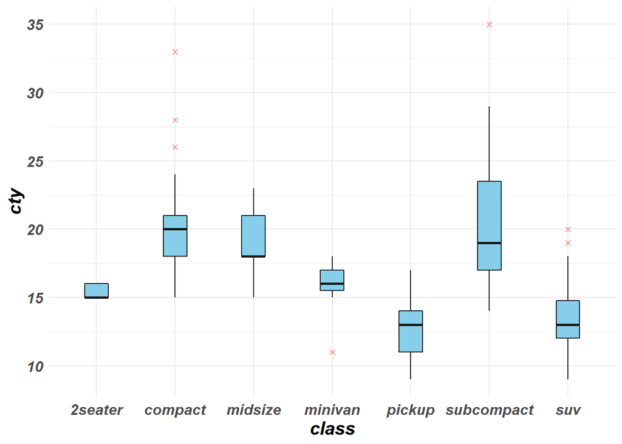

#### **p3**

#### 아래 보이는 것과 같이 데이터프레임 data_temp를 만들고,다음과 같은 라인차트를 만드시오. (color=lightskyblue, size=2)

#### hint) x축 눈금 설정 : scale_x_continuous(breaks=c())

```
##    month temp
## 1      1    1
## 2      2    4
## 3      3   11
## 4      4   18
## 5      5   23
## 6      6   26
## 7      7   28
## 8      8   29
## 9      9   35
## 10    10   18
## 11    11   11
## 12    12    4
```

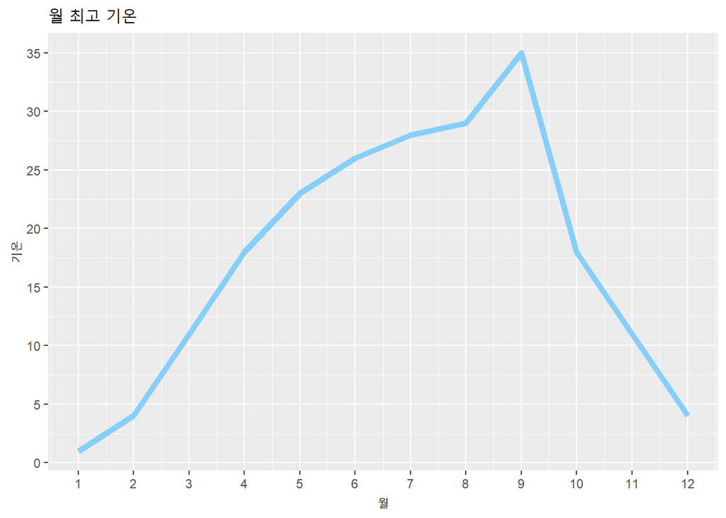

#### **p4**

#### airquality 데이터에서 month, day 변수를 제거하여 new_air에 할당한 뒤, 결측치를 제거하고(na.omit 함수 이용)

#### new_air의 변수끼리의 상관계수를 구하고, corrplot 패키지를 이용하여 상관계수를 시각화하시오.

#### corrplot에서의 method는 “ellipse”로 지정하시오.

```
##   Ozone Solar.R Wind Temp
## 1    41     190  7.4   67
## 2    36     118  8.0   72
## 3    12     149 12.6   74
## 4    18     313 11.5   62
## 7    23     299  8.6   65
## 8    19      99 13.8   59
```

```
##              Ozone    Solar.R       Wind       Temp
## Ozone    1.0000000  0.3483417 -0.6124966  0.6985414
## Solar.R  0.3483417  1.0000000 -0.1271835  0.2940876
## Wind    -0.6124966 -0.1271835  1.0000000 -0.4971897
## Temp     0.6985414  0.2940876 -0.4971897  1.0000000
```

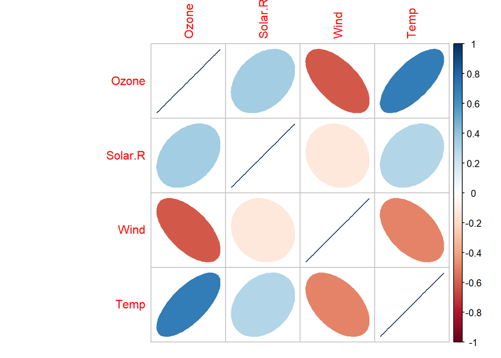

#### **p5**

#### diamonds 데이터를 판매된 자료로 보고, cut을 기준으로 clarity가 동일한 자료들의 price를 합해보자.

#### 그리고 이를 바탕으로 treemap를 그려보자.

#### hint) aggregate 함수를 사용

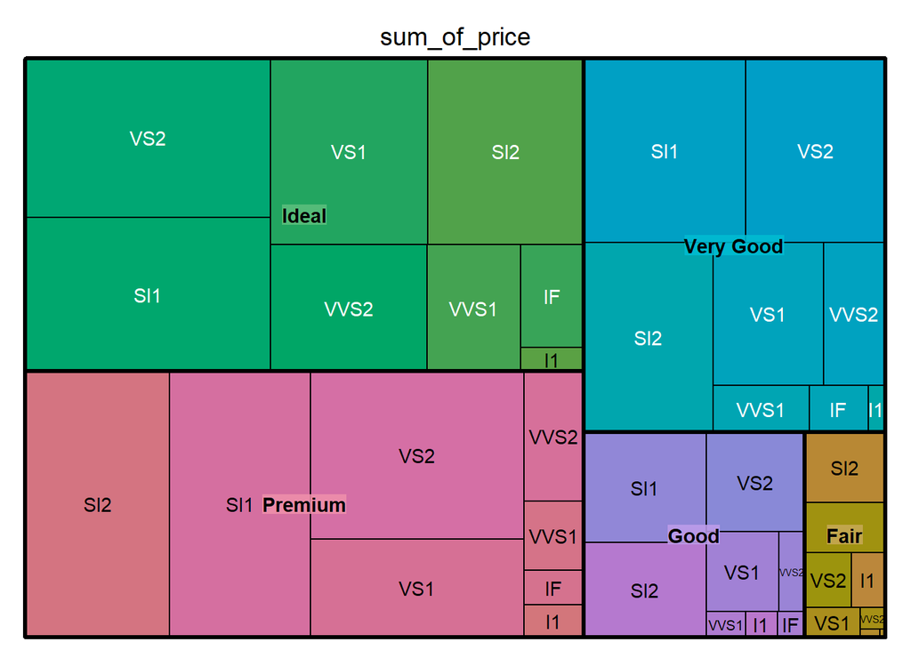